# Assignment 2 Notebook

James McKinlay, B00867096

## Introduction:

I have decided to choose the automobile directory from the list of choices given. This data set contains details and data about the automobiles from 1985. This data set contains 26 different attributes for automobiles, ranging from safety ratings, insurance risks, vehicle specifications, and average loss information. It contains this information on a number of different manufacturers, some located in North America, some from Europe, and some from Asia.  
**I will be trying to determine:**  
1)Which manufacturer has the best vehicles in the categories of engine size, price, highway-mpg and city-mpg.  
2)The correlation between highway and city mpg, price of vehicle, and which manufacturer rates the highest.  
3)The correlation between engine size and both highway and city mpg.

```r
library(tidyverse)
```

Reading in the data set

```r
import_data <- read.csv("C:/Users/jmcki/OneDrive/Desktop/School/3141/Assignment2/imports-85.data")
import_names <- read.csv("C:/Users/jmcki/OneDrive/Desktop/School/3141/Assignment2/imports-85.names")
```

## Data Cleaning:

In this section of code, I am retrieving the column names from the .names file and attaching them to the data frame. To do this I initially created a vector with the text from the .names file, then split the period and space from the name, as well as the colon. I then trimmed out the empty lines (lines 4 to 6 respectively) which were in place because of another column, and added the names to the data frame import_data.  
I also cleaned up the columns, as there were several sections of missing data (shown as a “?” in the data set), and replaced the missing data with an NA.

```r
#import_data
text <- read_lines("C:/Users/jmcki/OneDrive/Desktop/School/3141/Assignment2/imports-85.names")
#text[61:89]
names <- str_split_fixed(text[61:89], "\\. ",n=2)[,2]
names <- str_split_fixed(names, ":", n=2)[,1]
names <- names[-4:-6]
colnames(import_data)[1:26] <- names
#which(import_data=="?")
import_data <- replace(import_data, import_data=="?", NA)
import_data[, c(26)] <- sapply(import_data[, c(26)], as.numeric)
```

### Univariate Analysis

#### Summary of data:

```r
summary(import_data)
```

```
##    symboling       normalized-losses      make            fuel-type
##  Min.   :-2.0000   Length:204         Length:204         Length:204
##  1st Qu.: 0.0000   Class :character   Class :character   Class :character
##  Median : 1.0000   Mode  :character   Mode  :character   Mode  :character
##  Mean   : 0.8235
##  3rd Qu.: 2.0000
##  Max.   : 3.0000
##
##   aspiration        num-of-doors        body-style        drive-wheels
##  Length:204         Length:204         Length:204         Length:204
##  Class :character   Class :character   Class :character   Class :character
##  Mode  :character   Mode  :character   Mode  :character   Mode  :character
##
##
##
##
##  engine-location      wheel-base         length          width
##  Length:204         Min.   : 86.60   Min.   :141.1   Min.   :60.30
##  Class :character   1st Qu.: 94.50   1st Qu.:166.3   1st Qu.:64.08
##  Mode  :character   Median : 97.00   Median :173.2   Median :65.50
##                     Mean   : 98.81   Mean   :174.1   Mean   :65.92
##                     3rd Qu.:102.40   3rd Qu.:183.2   3rd Qu.:66.90
##                     Max.   :120.90   Max.   :208.1   Max.   :72.30
##
##      height       curb-weight   engine-type        num-of-cylinders
##  Min.   :47.80   Min.   :1488   Length:204         Length:204
##  1st Qu.:52.00   1st Qu.:2145   Class :character   Class :character
##  Median :54.10   Median :2414   Mode  :character   Mode  :character
##  Mean   :53.75   Mean   :2556
##  3rd Qu.:55.50   3rd Qu.:2939
##  Max.   :59.80   Max.   :4066
##
##   engine-size    fuel-system            bore              stroke
##  Min.   : 61.0   Length:204         Length:204         Length:204
##  1st Qu.: 97.0   Class :character   Class :character   Class :character
##  Median :119.5   Mode  :character   Mode  :character   Mode  :character
##  Mean   :126.9
##  3rd Qu.:142.0
##  Max.   :326.0
##
##  compression-ratio  horsepower          peak-rpm            city-mpg
##  Min.   : 7.000    Length:204         Length:204         Min.   :13.00
##  1st Qu.: 8.575    Class :character   Class :character   1st Qu.:19.00
##  Median : 9.000    Mode  :character   Mode  :character   Median :24.00
##  Mean   :10.148                                          Mean   :25.24
##  3rd Qu.: 9.400                                          3rd Qu.:30.00
##  Max.   :23.000                                          Max.   :49.00
##
##   highway-mpg        price
##  Min.   :16.00   Min.   : 5118
##  1st Qu.:25.00   1st Qu.: 7775
##  Median :30.00   Median :10270
##  Mean   :30.77   Mean   :13206
##  3rd Qu.:34.50   3rd Qu.:16501
##  Max.   :54.00   Max.   :45400
##                  NA's   :4
```

#### Mean data:

```r
mean_hw_mpg <- mean(import_data$`highway-mpg`)
mean_city_mpg <- mean(import_data$`city-mpg`)
mean_price <- mean(import_data$`price`, na.rm=TRUE)
mean_engine_size <- mean(import_data$`engine-size`, na.rm=TRUE)
print(mean_city_mpg)
```

```
## [1] 25.2402
```

```r
print(mean_hw_mpg)
```

```
## [1] 30.76961
```

```r
print(mean_price)
```

```
## [1] 13205.69
```

```r
print(mean_engine_size)
```

```
## [1] 126.8922
```

From the data above, I can conclude that there is an average city mpg of 25.24mpg, an average highway mpg of 30.77mpg, an average price of $13205.69, and an average engine size of 126.89 across all vehicles in the data set.

#### Median data:

```r
median_city_mpg <- median(import_data$`city-mpg`)
median_hw_mpg <- median(import_data$`highway-mpg`)
median_price <- median(import_data$price, na.rm=TRUE)
median_engine_size <- median(import_data$`engine-size`, na.rm=TRUE)
print(median_hw_mpg)
```

```
## [1] 30
```

```r
print(median_city_mpg)
```

```
## [1] 24
```

```r
print(median_price)
```

```
## [1] 10270
```

```r
print(median_engine_size)
```

```
## [1] 119.5
```

From the data above, I can conclude that there is a median city mpg of 24, a median highway mpg of 30, a median price of $10270, and a median engine size of 119.5.

#### Max, min, and range:

```r
max_hw_mpg <- max(import_data$`highway-mpg`)
min_hw_mpg <- min(import_data$`highway-mpg`)
max_city_mpg <- max(import_data$`city-mpg`)
min_city_mpg <- min(import_data$`city-mpg`)
max_price <- max(import_data$price, na.rm=TRUE)
min_price <- min(import_data$price, na.rm=TRUE)
max_engine_size <- max(import_data$`engine-size`, na.rm=TRUE)
min_engine_size <- min(import_data$`engine-size`, na.rm=TRUE)
range_hw_mpg <- max_hw_mpg - min_hw_mpg
range_city_mpg <- max_city_mpg - min_city_mpg
range_price <- max_price - min_price
range_engine_size <- max_engine_size - min_engine_size

print(max_hw_mpg)
```

```
## [1] 54
```

```r
print(min_hw_mpg)
```

```
## [1] 16
```

```r
print(range_hw_mpg)
```

```
## [1] 38
```

```r
print(max_city_mpg)
```

```
## [1] 49
```

```r
print(min_city_mpg)
```

```
## [1] 13
```

```r
print(range_city_mpg)
```

```
## [1] 36
```

```r
print(max_price)
```

```
## [1] 45400
```

```r
print(min_price)
```

```
## [1] 5118
```

```r
print(range_price)
```

```
## [1] 40282
```

```r
print(max_engine_size)
```

```
## [1] 326
```

```r
print(min_engine_size)
```

```
## [1] 61
```

```r
print(range_engine_size)
```

```
## [1] 265
```

There is a range of 38mpg across vehicles for highway driving with a maximum of 54mpg and a minimum of 16mpg, and a 36mpg for city driving with a maximum of 49mpg and a minimum of 13mpg. There is also a range of $40282 between all vehicles in the data set, with a maximum price of $45400 and a minimum price of $5118. Finally, there is a range of 265 across all engine sizes, with the maximum size being 326 and the minimum size being 61.

#### Tibbles for use in ggplots:

In this section, I am manipulating some specific mean data into its own vectors for later use.

```r
hw_mpg <- import_data %>% group_by(make) %>% summarise(mean_hw_mpg = mean(`highway-mpg`))
city_mpg <- import_data %>% group_by(make) %>% summarise(mean_city_mpg = mean(`city-mpg`))
price_ <- import_data %>% group_by(make) %>% summarise(price=mean(`price`))
hw_mpg
```

| make | mean_hw_mpg |
| --- | --- |
| alfa-romero | 26.50000 |
| audi | 24.14286 |
| bmw | 25.37500 |
| chevrolet | 46.33333 |
| dodge | 34.11111 |
| honda | 35.46154 |
| isuzu | 36.00000 |
| jaguar | 18.33333 |
| mazda | 31.94118 |
| mercedes-benz | 21.00000 |

[output cut: 12 more lines]

```r
city_mpg
```

| make | mean_city_mpg |
| --- | --- |
| alfa-romero | 20.00000 |
| audi | 18.85714 |
| bmw | 19.37500 |
| chevrolet | 41.00000 |
| dodge | 28.00000 |
| honda | 30.38462 |
| isuzu | 31.00000 |
| jaguar | 14.33333 |
| mazda | 25.70588 |
| mercedes-benz | 18.50000 |

[output cut: 12 more lines]

```r
price_
```

| make | price |
| --- | --- |
| alfa-romero | 16500.000 |
| audi | NA |
| bmw | 26118.750 |
| chevrolet | 6007.000 |
| dodge | 7875.444 |
| honda | 8184.692 |
| isuzu | NA |
| jaguar | 34600.000 |
| mazda | 10652.882 |
| mercedes-benz | 33647.000 |

[output cut: 12 more lines]

#### Tables of import data to be used (make, engine size, price, highway and city mpg):

Number of vehicles by make for each manufacturer in the data set

```r
table(import_data$make)
```

```
##
##   alfa-romero          audi           bmw     chevrolet         dodge
##             2             7             8             3             9
##         honda         isuzu        jaguar         mazda mercedes-benz
##            13             4             3            17             8
##       mercury    mitsubishi        nissan        peugot      plymouth
##             1            13            18            11             7
##       porsche       renault          saab        subaru        toyota
##             5             2             6            12            32
##    volkswagen         volvo
##            12            11
```

Engine sizes for all vehicles in the data set

```r
table(import_data$`engine-size`)
```

```
##
##  61  70  79  80  90  91  92  97  98 103 108 109 110 111 119 120 121 122 130 131
##   1   3   1   1  12   5  15  14  14   1  13   8  12   1   1   7   6  15   3   2
## 132 134 136 140 141 145 146 151 152 156 161 164 171 173 181 183 194 203 209 234
##   2   2   5   2   7   1   6   1   6   5   1   3   3   1   6   4   3   1   3   2
## 258 304 308 326
##   2   1   1   1
```

All prices for vehicles in the data set

```r
table(import_data$price)
```

```
##
##  5118  5151  5195  5348  5389  5399  5499  5572  6095  6189  6229  6295  6338
##     1     1     1     1     1     1     1     2     1     1     2     1     1
##  6377  6479  6488  6529  6575  6649  6669  6692  6695  6785  6795  6849  6855
##     1     1     1     1     1     1     1     2     1     1     1     1     1
##  6918  6938  6989  7053  7099  7126  7129  7198  7295  7299  7349  7395  7463
##     1     1     1     1     1     1     1     1     2     1     1     1     1
##  7499  7603  7609  7689  7738  7775  7788  7799  7895  7898  7957  7975  7995
##     1     1     2     1     1     2     1     1     1     2     2     1     1
##  7999  8013  8058  8189  8195  8238  8249  8358  8449  8495  8499  8558  8778
##     1     1     1     1     1     1     1     1     1     2     1     1     1
##  8845  8921  8948  8949  9095  9233  9258  9279  9295  9298  9495  9538  9549
##     2     2     1     1     1     1     1     2     1     1     1     1     1
##  9639  9895  9959  9960  9980  9988  9989  9995 10198 10245 10295 10345 10595
##     1     1     1     1     1     1     1     1     1     1     1     1     1
```

[output cut: 16 more lines]

All highway-mpg in data set

```r
table(import_data$`highway-mpg`)
```

```
##
## 16 17 18 19 20 22 23 24 25 26 27 28 29 30 31 32 33 34 36 37 38 39 41 42 43 46
##  2  1  2  2  2  8  7 17 19  3  4 13 10 16  8 16  9 14  2 13 17  2  3  3  4  2
## 47 50 53 54
##  2  1  1  1
```

All city-mpg in the data set

```r
table(import_data$`city-mpg`)
```

```
##
## 13 14 15 16 17 18 19 20 21 22 23 24 25 26 27 28 29 30 31 32 33 34 35 36 37 38
##  1  2  3  6 13  3 27  3  7  4 12 22  8 12 14  7  3  8 28  1  1  1  1  1  6  7
## 45 47 49
##  1  1  1
```

### Bivariate Analysis

#### Mean highway mpg by make:

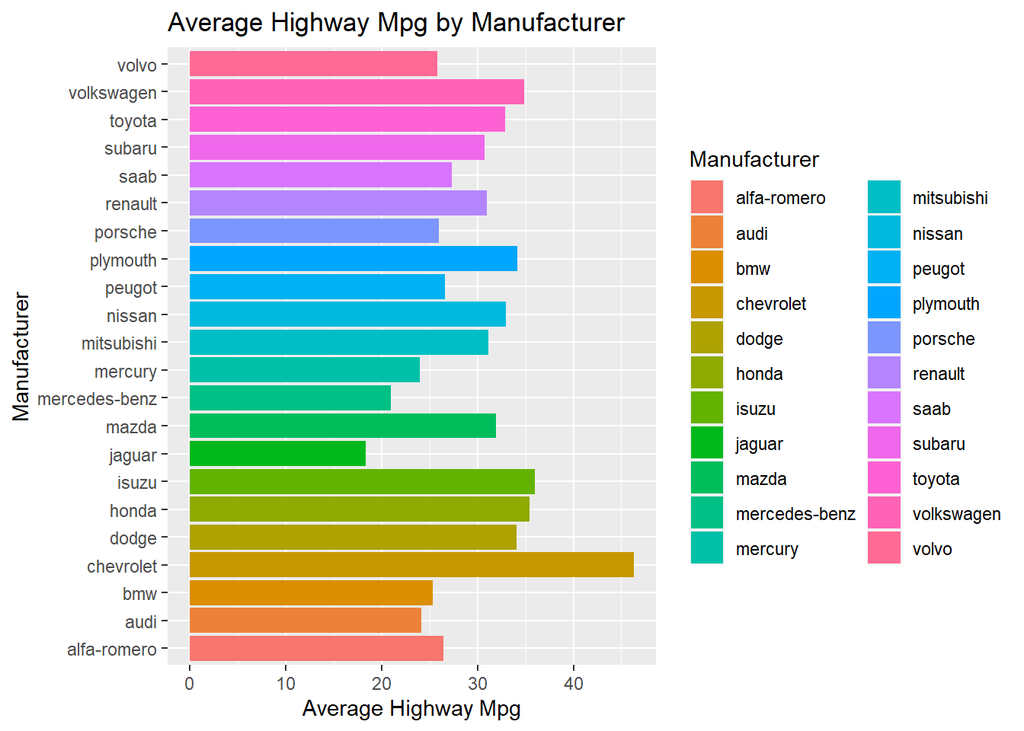

```r
hw_mpg_plot <- hw_mpg %>% group_by(make) %>% ggplot(aes(x=make, y=mean_hw_mpg, fill=make)) + geom_bar(stat="identity") + coord_flip()
hw_mpg_plot + ggtitle("Average Highway Mpg by Manufacturer") + xlab("Manufacturer") + ylab("Average Highway Mpg") + labs(fill = "Manufacturer")
```

#### Mean city mpg by make:

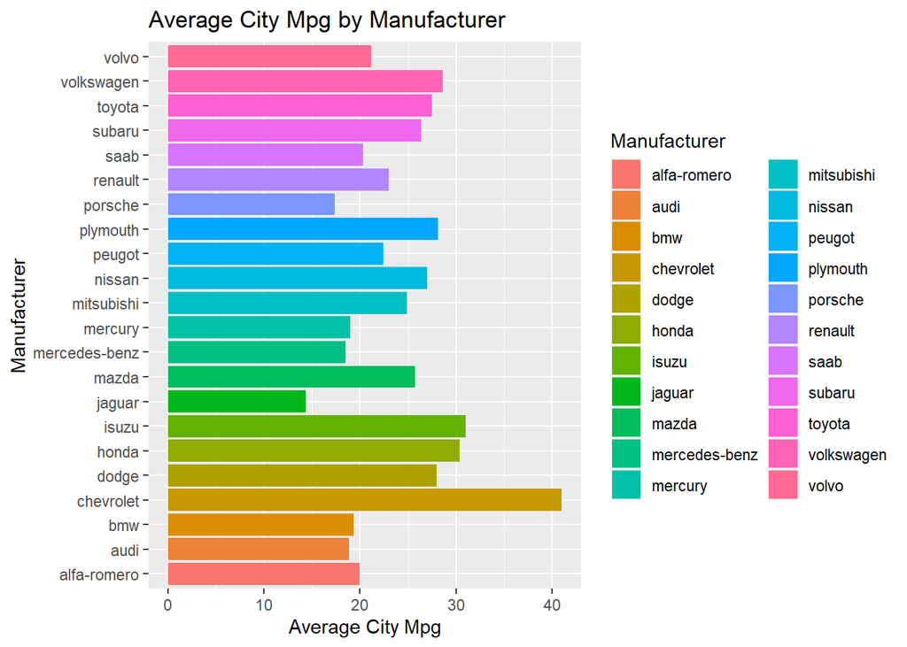

```r
city_mpg_plot <- city_mpg %>% group_by(make) %>% ggplot(aes(x=make, y=mean_city_mpg, fill=make)) + geom_bar(stat="identity") + coord_flip()
city_mpg_plot + ggtitle("Average City Mpg by Manufacturer") + xlab("Manufacturer") + ylab("Average City Mpg") + labs(fill = "Manufacturer")
```

As we can see from the two graphs (above), Chevrolet quite clearly has the best mpg in both the highway (46.3) and city (41.0) categories. They are followed by Isuzu (36.0, 31.0) and Honda (35.5, 30.4) respectively. We can also see that Jaguar (18.3, 14.3) is quite far behind in both categories.

#### Graphs for highway and city mpg vs engine size by make:

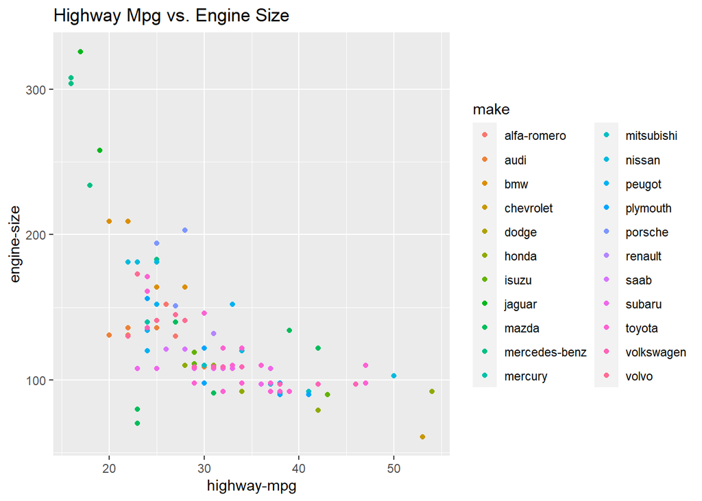

```r
plot1<- ggplot(data=import_data, aes(x=`highway-mpg`, y=`engine-size`, group=`make`, color=`make`)) +  geom_point()
plot1 + ggtitle("Highway Mpg vs. Engine Size")
```

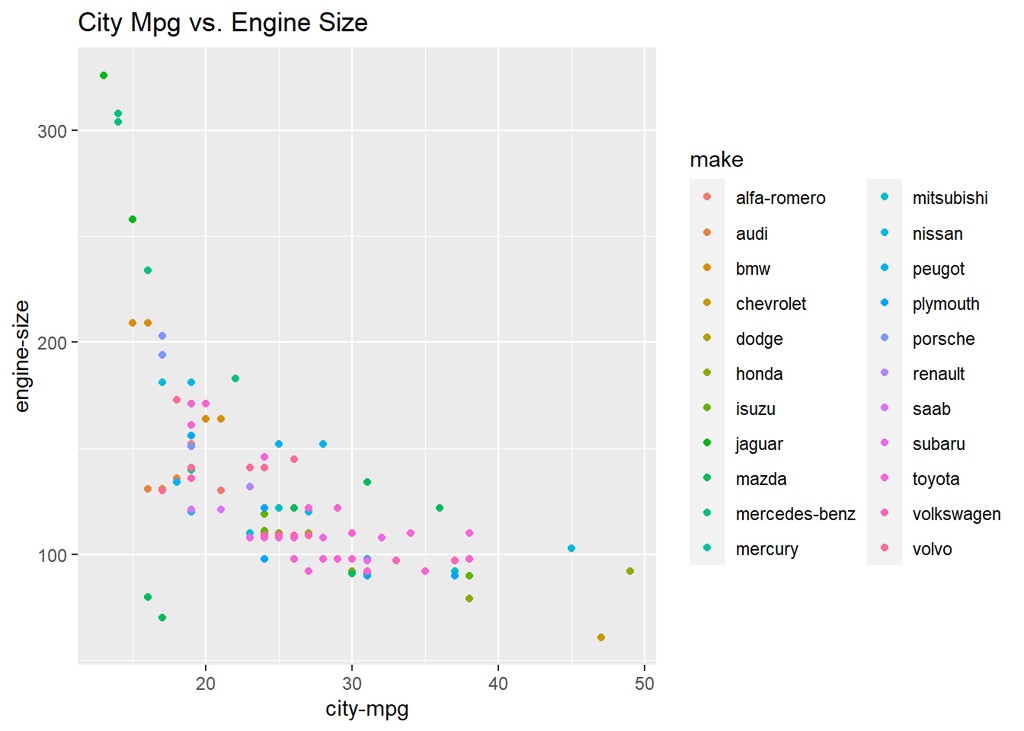

```r
plot2 <- ggplot(data=import_data, aes(x=`city-mpg`, y=`engine-size`, group=`make`, color=`make`)) + geom_point()
plot2 + ggtitle("City Mpg vs. Engine Size")
```

From these graphs, I can tell that there is a correlation between engine size and fuel efficiency. These findings corroborate my earlier findings with regards to average mpg (for both city and highway driving). As can be seen, the luxury manufacturers (Jaguar, Mercedes-Benz, BMW) all have large engine vehicles, with very low mpg, while manufacturers like Chevrolet, Honda, and Mitsubishi have relatively small engine vehicles, but with a much higher fuel efficiency.

#### Mean price by make:

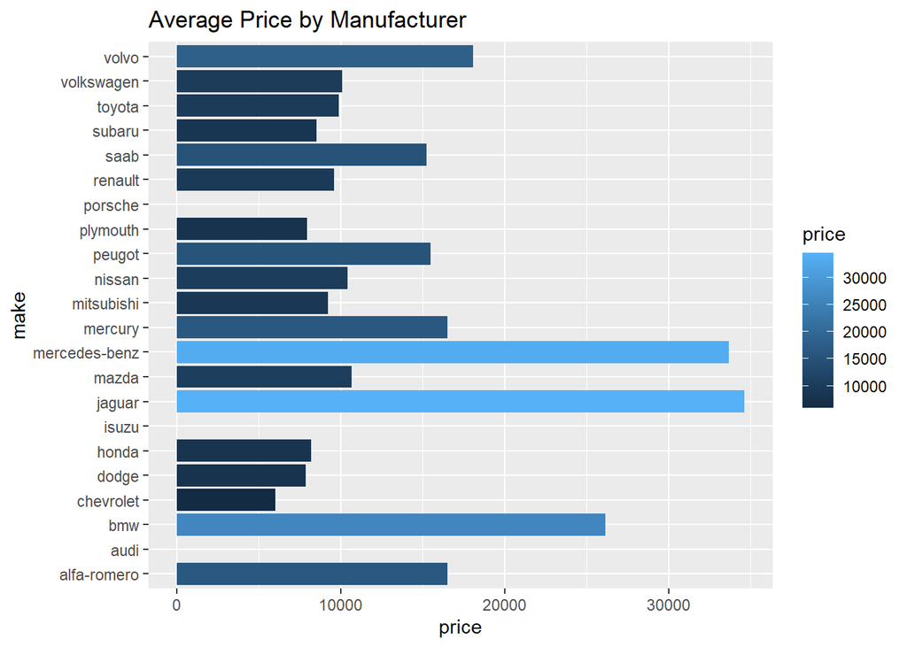

```r
price_plot <- price_ %>% group_by(make) %>% ggplot(aes(x=make, y=price, fill=price)) + geom_bar(stat="identity") + coord_flip()
price_plot + ggtitle("Average Price by Manufacturer")
```

As we can see above, Jaguar, Mercedes-Benz, and BMW are quite far ahead of the competition when it comes to price. This is not that surprising, as both manufacturers are luxury vehicle manufacturers, and their vehicles have to be imported, further increasing their value. We can also see that Chevrolet is the cheapest of the data set, as well as the most fuel efficient. We can also see that three of the manufacturers in the data set had missing prices, and had to be removed (Porsche, Isuzu, and Audi)

#### Highway vs city mpg by make and price:

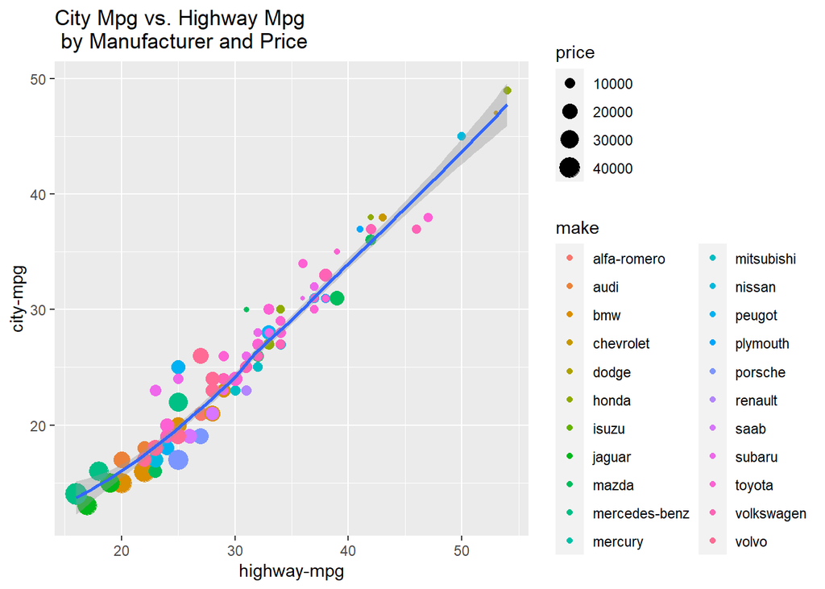

```r
comp_mpg <- import_data %>% ggplot(aes(x=`highway-mpg`, y=`city-mpg`)) + geom_point(aes(col=make, size=price), na.rm=TRUE) + geom_smooth()
comp_mpg + ggtitle("City Mpg vs. Highway Mpg \n by Manufacturer and Price")
```

As we can see from this graph, Jaguar and Mercedes-Benz are at the bottom of not only the city and highway mpg averages, but also the most expensive vehicles. Along with previous calculations and observations, this is not a very surprising result, as both manufacturers are concerned with luxury vehicles, as well as being imported into our market, which drives their price up.

#### Outliers found in engine size, highway and city mpg, and price by make:

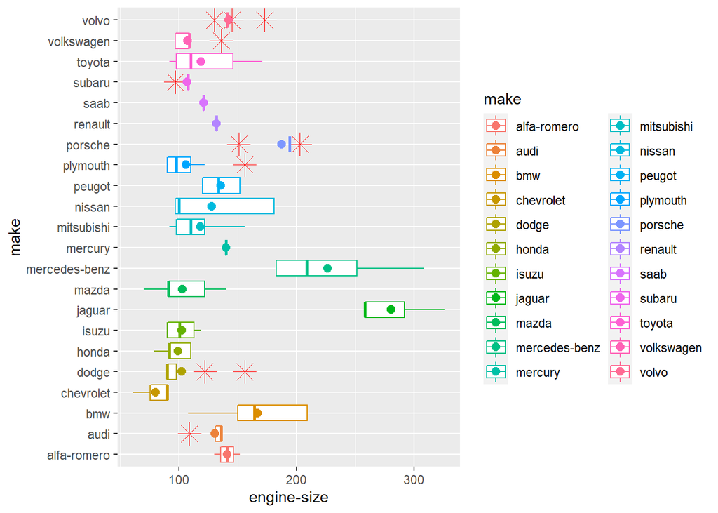

```r
engine_size_outliers_plot <- ggplot(data=import_data, aes(x=`engine-size`, y=`make`, color=`make`)) + geom_boxplot(outlier.color="red", outlier.shape=8, outlier.size=5)
engine_size_outliers_plot + stat_summary(fun=mean, geom="point", shape=20, size=4)
```

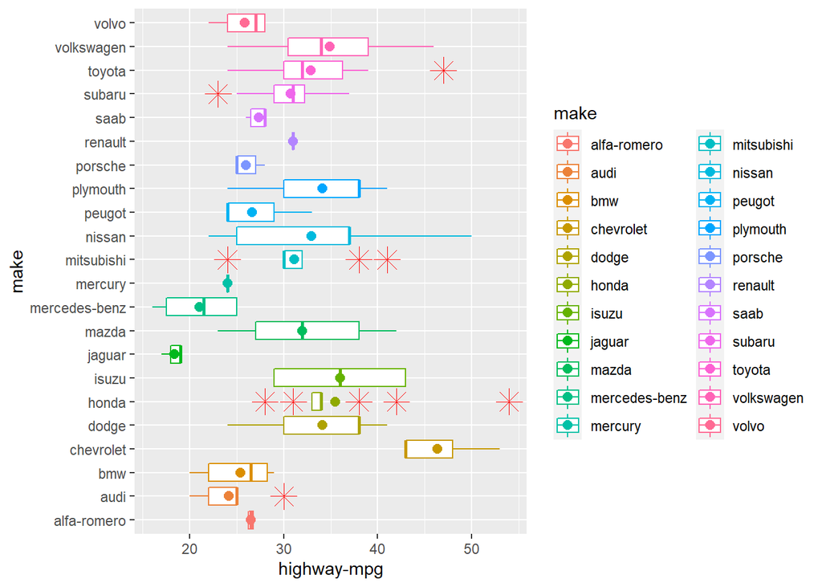

```r
outliers_highway_mpg <- ggplot(data=import_data, aes(x=`highway-mpg`, y=`make`, color=`make`)) + geom_boxplot(outlier.color="red", outlier.shape=8, outlier.size=5)
outliers_highway_mpg + stat_summary(fun=mean, geom="point", shape=20, size=4)
```

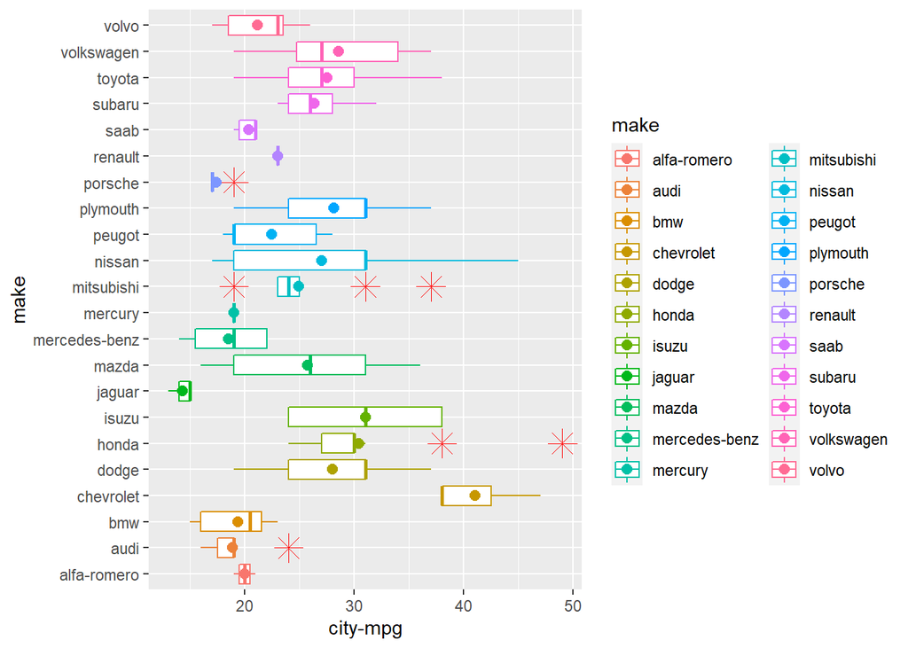

```r
outliers_city_mpg <- ggplot(data=import_data, aes(x=`city-mpg`, y=`make`, color=`make`)) + geom_boxplot(outlier.color="red", outlier.shape=8, outlier.size=5)
outliers_city_mpg + stat_summary(fun=mean, geom="point", shape=20, size=4)
```

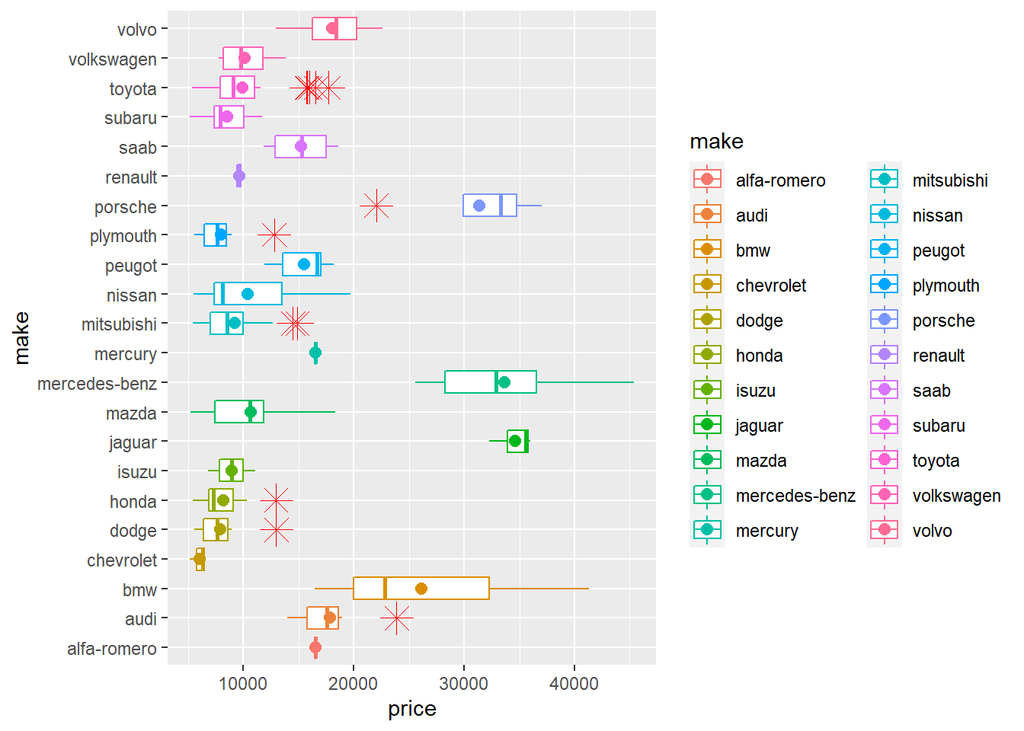

```r
outliers_price <- ggplot(data=import_data, aes(x=`price`, y=`make`, color=`make`)) + geom_boxplot(outlier.color="red", outlier.shape=8, outlier.size=5)
outliers_price + stat_summary(fun=mean, geom="point", shape=20, size=4)
```

## Conclusion:

To begin with, I was very surprised to see that Chevrolet came first in both the mpg categories, as well as having the lowest average price per vehicle. However, I feel that my data may be somewhat skewed because there are only **three** instances of Chevrolet’s in the data set, while there are **thirty-two** vehicles for Toyota present in the set. Going into this analysis, I had assumed that either Honda, Mitsubishi, or Toyota would be the most fuel efficient based on my personal experience. Research conducted in 2022 also supports my claim as, for non-hybrid vehicles (as it does not seem fair to compare hybrid to non hybrid), the Mitsubishi Mirage, the Hyundai Elantra, and the Honda Civic seem to be the most fuel efficient vehicles (1,2,3). Of these three manufacturer’s, only Honda appears in the top three for the data set. Another surprise for the most fuel efficient vehicles was Isuzu. Isuzu does not even sell cars in North America anymore, as it primarly produces trucks (though again, this data might be skewed since there are only four Isuzu’s in the data set).

After my preliminary analysis and observations, I decided to try and figure out how these manfacturers compared to the manufacturers of the present with regards to fuel efficiency, and was quite surprised by the results. With Chevrolet being the highest rated in both fuel efficiency and price, I was slightly dismayed to find that, although there have been many breakthroughs in fuel efficiency and manufacturing upgrades, the highway and city mpg of 1985 vehicles is relatively similar to those of the modern era. I decided to ignore hybrid/electric vehicles, as it is not a realistic comparison between the two drive types (petrol powered vs. hybrid), as hybrid will always be more fuel efficient. I found that top rated vehicles of modern manufacturers have a very similar mpg to those from thirty-seven years ago.

From my analysis, I can conclude that Chevrolet is the highest rated vehicle in terms of fuel efficiency, engine size, and price. Based on personal knowledge and of this data set, I can see that there has not been a large change in Chevrolet’s vehicles over the years, as they still prioritize many small, fuel efficient, and inexpensive vehicles across their range of vehicles in 2022.

### Citations:

Data Set: https://archive.ics.uci.edu/ml/machine-learning-databases/autos/  
1)https://www.cars.com/articles/what-are-the-most-fuel-efficient-cars-for-2022-447856/ 2)https://www.autobytel.com/coupes/car-buying-guides/the-10-most-fuel-efficient-non-hybrids-126560/ 3)https://www.carhp.com/news/top-10-most-fuel-efficient-non-hybrid-cars 4)http://www.sthda.com/english/wiki/ggplot2-box-plot-quick-start-guide-r-software-and-data-visualization